# Hypothesis Testing

Aarushi Verma

2022-07-13

## Introduction

In this section we focus on the first part of the prompt, which asks us to analyze the motivations for lending among Kiva contributors to developing nation entrepreneurs. Our approach here is suitable for students with limited statistical background: we first explore the general characteristics of borrowers, then we contrast the characteristics of funded borrowers to those of non-funded borrowers, using both descriptive statistics and hypothesis testing. Since lenders choose whom they fund, the results of this analysis will reveal the types of borrowers which lenders prefer, and may suggest motivations for lending.

## Setup

Before we dive into the analysis, we need to import all the required packages. This includes packages for statistical analysis and visualization - many of which you will be familiar with from earlier sections.

### Importing the required packages

The packages we use in this walk through are:

```r
library("ggplot2")
library("plotly")
library("tidyverse")
library("readr")
library("colorblindr")
library("viridis")
library("memisc")
library("kableExtra")
library("scales")
options(readr.show_col_types = FALSE)
```

### Reading the data

We use the `lender loans` and `loans` files for this analysis. The `lender loans` file contains detailed loans and lender information with corresponding borrowers. The `loans` file has detailed borrower information and their respective loans, however this file does not contain any lender information.

Our prompt relates to motivations for lending to developing-nation entrepreneurs, therefore to focus on the appropriate borrowers we subset our data. While the term “developing nation” is not clearly defined, we use data from world bank to separate the borrowers’ countries into low income and high income groups in the `lender loans` file. We perform this step using a `left_join` and use the updated data set for the rest of our analysis

```r
wdi <- read_csv("data/CLASS.csv") # World Bank Indicator data
lender_loans <- read_csv("data/lender_loans.csv") #Kiva Lender Loans data
kiva_loan <- read_csv(("data/loans.csv")) #Loans data

#Merging data to incorporate income indicators in our lender loan's file using country names
kiva_ll<- left_join(lender_loans, wdi, by = c("location.country" = "Economy"))

kiva_ll <- subset(kiva_ll, select = -c(52,54:55)) #Removing irrelevant columns
colnames(kiva_ll)[52] <- "income_indicator" #renaming income group column to income indicator
```

## Analysis

### Descriptive Statistics

We begin by getting an overview of the characteristics of all would-be borrowers, including their gender, sector, country, and requested loan amount. First we look at how the total amount of loans received varies between high income and low income countries using a bar chart. From this, we observe that countries belonging to lower income group receive the majority of loan funds.

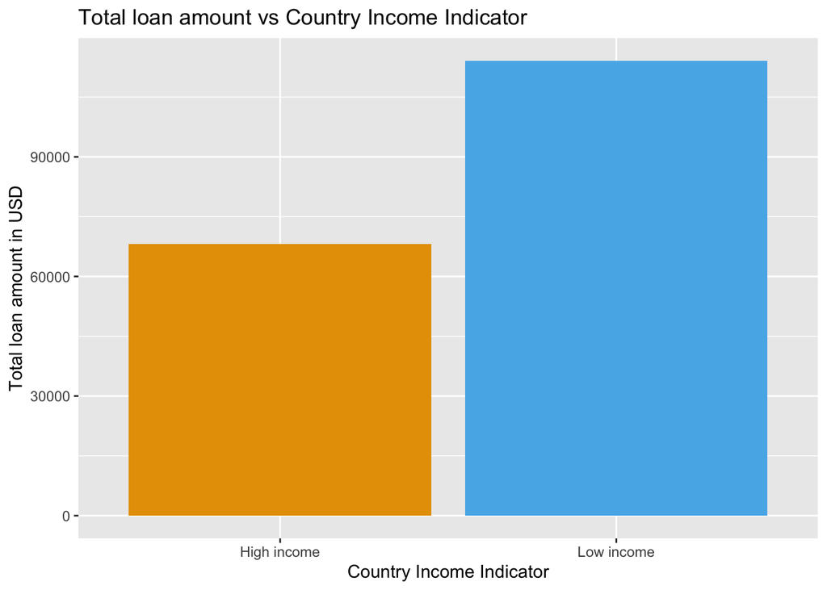

```r
#sorting income indicators into two broad groups - High Income and Low income for ease of analysis
kiva_ll$income_indicator[kiva_ll$income_indicator=="Lower middle income"]<-"Low income"
kiva_ll$income_indicator[kiva_ll$income_indicator=="Upper middle income"]<-"High income"

# Loan Amount Calculation
income_group <- kiva_ll %>% group_by(income_indicator) %>%
        summarize(tot_loans = sum(loan_amount)/1000) %>%
  arrange(desc(tot_loans))

#Bar Chart country indicator vs Loan Amount
ggplot(na.omit(income_group)) +
  aes(income_indicator, tot_loans, fill =income_indicator) +
  geom_bar(stat="identity") +
  xlab("Country Income Indicator") +
  ylab("Total loan amount in USD") +
  scale_fill_OkabeIto(order = c(1,2)) +
  ggtitle("Total loan amount vs Country Income Indicator") +
   theme(legend.position = "none")
```

Keeping our prompt in mind, we subset our data to these low income countries and perform the rest of the analysis on that subset.

```r
kiva_ll <- kiva_ll %>% filter(income_indicator=="Low income")
```

Because we are interested in differences between funded and non-funded borrowers, we add an indicator for borrower type (sex of the borrower: male, female, or group borrower) and funding status to our data set.

**Borrower Type**

Our current master file `lender_loans_with_wbi.csv` only contains the total number of borrowers. However, the `loans.csv` file contains a split of the count of female and male borrowers. Using this information we can create a new variable which indicates whether a borrower is an individual male borrower, individual female borrower or part of a group. We use the `mutate` function to create this new column and name it `bor_type`. We update the values based on `if_else` conditions. We apply these conditions on the male borrower and female borrower count column. The conditions we use are:

- If the value in the m_borrower_count column is equal to 1 and f_borrower_count is equal to 0, we update the value in the `bor_type` column as *Male*
- If the value in the f_borrower_count column is equal to 1 and m_borrower_count is equal to 0, we update the value in the `bor_type` column as *Female*
- For any other case, we update the value in the `bor_type` column as *Group*

```r
#Get unique borrower id and total male female borrower count
kiva_loan_sub <- kiva_loan %>% group_by(borrower_image_id) %>%
  summarize(total_m = sum(borrower_m_count),total_f = sum(borrower_f_count))

#Create new borrower type column based on conditions
kiva_loan_sub <- kiva_loan_sub %>%
  mutate(bor_type = if_else(total_m == 1 & total_f == 0, "Male",
                       if_else(total_m == 0 & total_f == 1, "Female","Group")))
```

After creating the indicator variable, we merge those values to the `lender_loans` data frame and check for NAs. This will help us verify if all the values in our left data frame have found corresponding values or not. For the purpose of this analysis we will drop any NAs in the data since it is not possible to obtain that information elsewhere.

```r
#Checking if each borrower image id maps to 1 Gender or group
kiva_loan_sub %>%
  group_by(borrower_image_id) %>%
  summarize(count=n_distinct(bor_type)) %>%
  arrange(desc(count))

#Merging sex group to main data
kiva_ll_merged <- left_join(x = kiva_ll, y = kiva_loan_sub, by="borrower_image_id")
```

**Funding Status**

Our data contains a `status` column which indicates the current status of the loan. First we look at the unique values in this column and the number of loans associated with each respectively. Further, we use these values to create an indicator variable for whether a loan has been funded or not.

```r
#Looking at unique values and respective loan count in status column
status <- kiva_ll_merged %>% group_by(status) %>% summarize(count = length(unique(loan_id))) %>% arrange(desc(count))

status %>% kbl(caption = "Value Counts of Status column", col.names = c("Status", "No. of loans")) %>%
  kable_classic(bootstrap_options ="striped",full_width = F, html_font = "helvetica",position = "left")
```

Value Counts of Status column

| Status | No. of loans |
| --- | --- |
| paid | 48371 |
| in_repayment | 18844 |
| defaulted | 1144 |
| refunded | 748 |
| fundraising | 171 |
| expired | 132 |
| funded | 62 |

The status column contains 7 unique values. We look at the data dictionary and Kiva website to get a better idea of what each term means. Based on that we make the classification of these terms to our 2 classes funded and not-funded:

- Funded: $\texttt{funded, in_repayment, paid, defaulted, refunded}$
- Not Funded: $\texttt{expired, fundraising}$

```r
#creating a vector for values which are associated with funded loans
funded_vec <- c("paid","in_repayment","funded","defaulted", "refunded")

#create indicator variable for Funded or not funded loans
kiva_ll_funding <- kiva_ll_merged %>% mutate(funding_status = if_else(
                       kiva_ll_merged$status %in% funded_vec, "Funded","Not Funded"))
```

Once we have added our new indicator columns, we will use descriptive statistics to visualize these and identify trends,to gain some insight into borrower characteristics

We look at the distribution of the funding status of loans among borrower types.

```r
#Creating master df for all plots

bor_chr <- kiva_ll_funding %>% group_by(borrower_image_id,loan_id,income_indicator, location.country,sector,bor_type, funding_status) %>%
  summarize(tot_loans = sum(loan_amount)/100,borr_count = max(borrower_count)) %>% arrange(desc(tot_loans))
```

[output not shown]

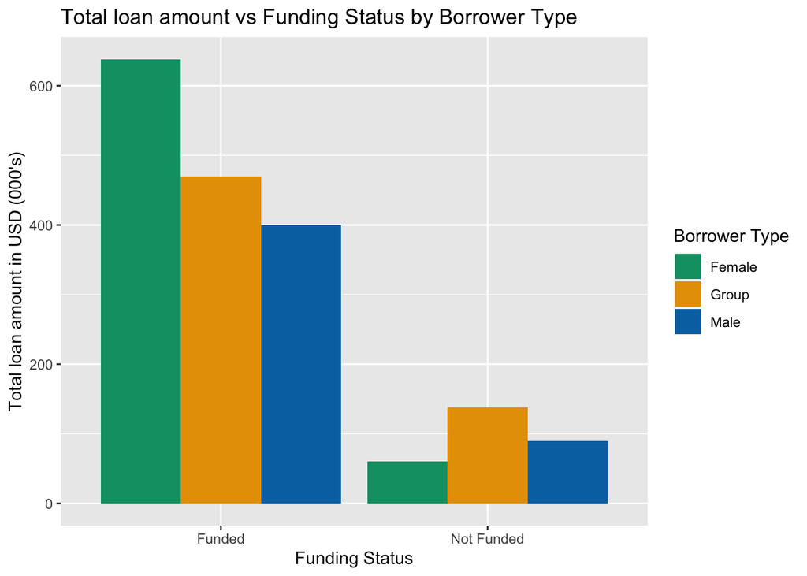

```r
bor_chr<- na.omit(bor_chr)
#Bar Chart Funding Status vs Loan Amount by Borrower Type
ggplot(bor_chr) +
  aes(funding_status, tot_loans, fill =bor_type) +
  geom_bar(stat="identity", position = "dodge") +
  xlab("Funding Status") +
  ylab("Total loan amount in USD (000's)") +
  scale_fill_OkabeIto(order = c(3,1,5)) +
  ggtitle("Total loan amount vs Funding Status by Borrower Type") +
  theme(strip.text.x = element_text(size = 16)) +
  labs(fill = "Borrower Type")
```

From the above plot we observe that Female borrowers receive the highest total loans whereas Male borrower’s receive the lowest.

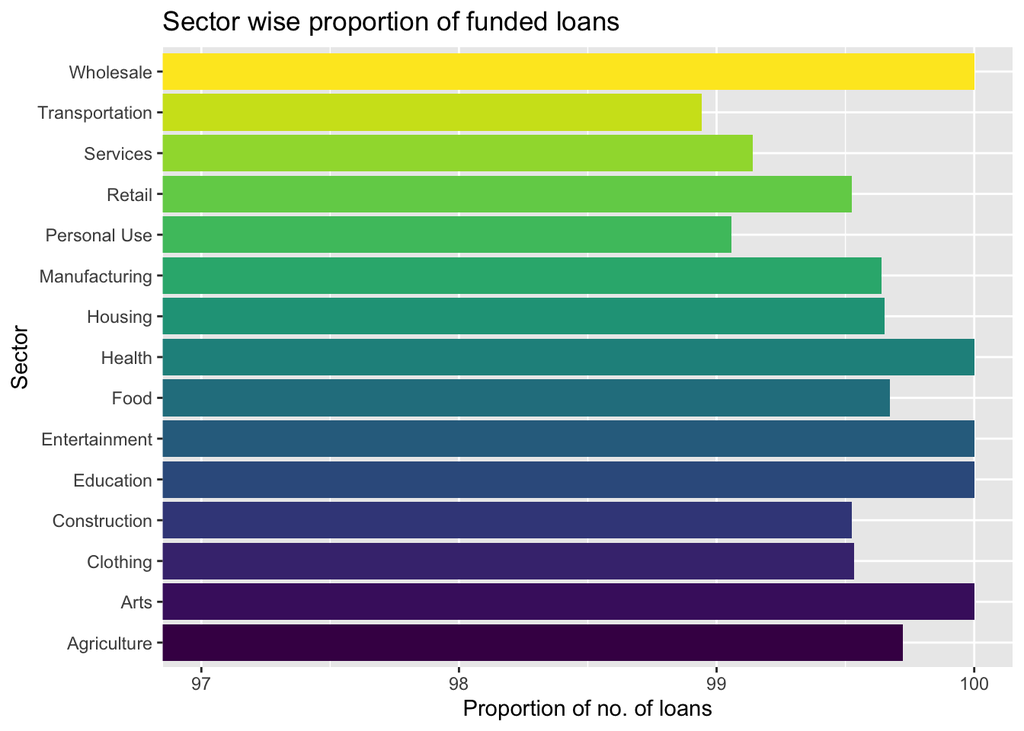

```r
#Funded by borrower type
funded_sec <- bor_chr %>% group_by(sector, funding_status) %>%
  summarize(loan_count = length(unique(loan_id))) %>%
  arrange(desc(sector))

funded_sec <- funded_sec %>% group_by(sector) %>%
  mutate(prop = (loan_count / sum(loan_count))*100)


ggplot(funded_sec) +
  aes(sector, prop, fill =sector) +
  geom_bar(stat="identity", position = "dodge") +
  xlab("Sector") +
  ylab("Proportion of no. of loans") +
  scale_fill_viridis(discrete = TRUE,option = "D") +
  ggtitle("Sector wise proportion of funded loans") +
  scale_y_continuous(limits = c(97,100),oob=rescale_none)+
  theme(strip.text.x = element_text(size = 16), legend.position = "None") +
  coord_flip()
```

Health and arts have a 100% funding rate. This could be due to various reasons. However we can assume that this related to it being either a small number of loans or sectors that favored by lenders

We have looked at how the proportion of loans varies across sectors, next we look at how the average loan amount varies across sectors, for our indicators. Since the number of borrowers is not evenly distributed across types in our data, looking at the average loan amount helps to make the comparisons more material.

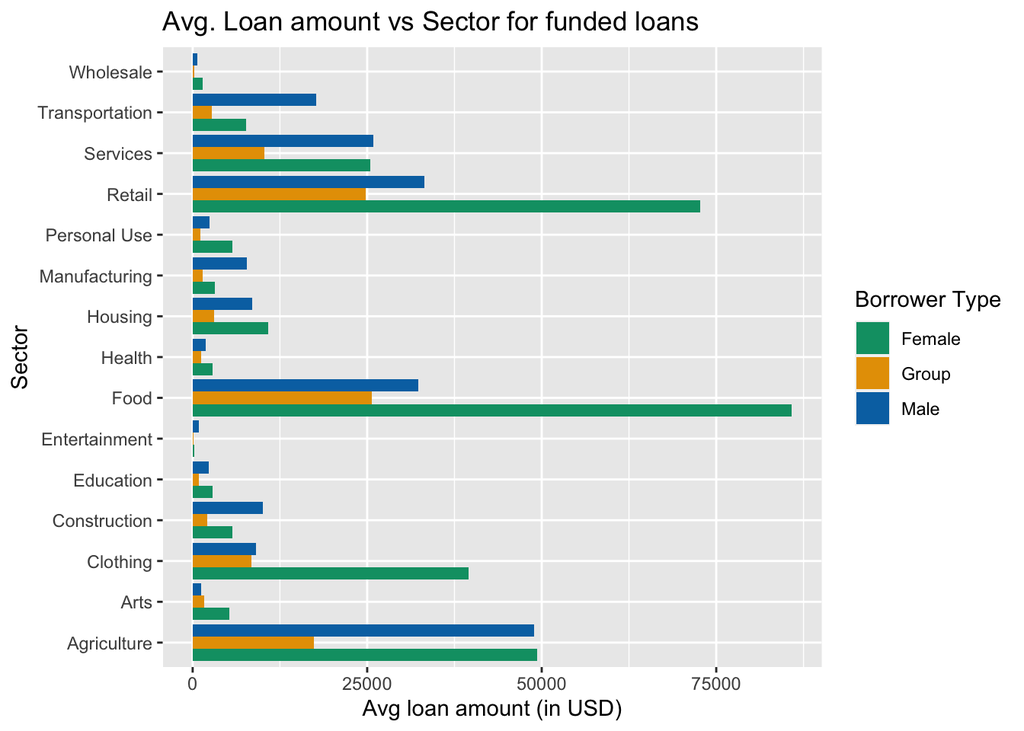

```r
loan_funded <- bor_chr %>%  filter(funding_status=="Funded")
loan_nonfunded <- bor_chr %>%  filter(funding_status == "Not Funded")


percap_loan_fun <- loan_funded %>% mutate(amount_per_cap= tot_loans/borr_count)
percap_loan_nonfun <- loan_nonfunded %>% mutate(amount_per_cap= tot_loans/borr_count)


#Funded by borrower type
percap_funded_sec <- percap_loan_fun %>% group_by(sector, bor_type) %>%
  summarize(avg_loan = sum(amount_per_cap))


ggplot(percap_funded_sec) +
  aes(sector, avg_loan, fill =bor_type) +
  geom_bar(stat="identity", position = "dodge") +
  xlab("Sector") +
  ylab("Avg loan amount (in USD)") +
  scale_fill_OkabeIto(order = c(3,1,5)) +
  ggtitle("Avg. Loan amount vs Sector for funded loans") +
  theme(strip.text.x = element_text(size = 16)) +
  coord_flip()+
  labs(fill = "Borrower Type")
```

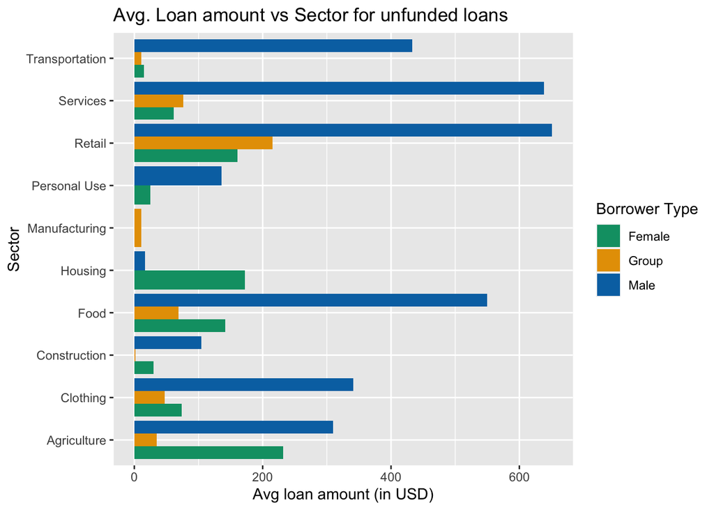

```r
# Not Funded by borrower type

percap_nonfunded_sec <- percap_loan_nonfun %>% group_by(sector, bor_type) %>%
  summarize(avg_loan = sum(amount_per_cap))


ggplot(percap_nonfunded_sec) +
  aes(sector, avg_loan, fill =bor_type) +
  geom_bar(stat="identity", position = "dodge") +
  xlab("Sector") +
  ylab("Avg loan amount (in USD)") +
  scale_fill_OkabeIto(order = c(3,1,5)) +
  ggtitle("Avg. Loan amount vs Sector for unfunded loans") +
  theme(strip.text.x = element_text(size = 16)) +
  coord_flip()+
  labs(fill = "Borrower Type")
```

We observe that for funded loans, female borrowers have a significantly higher average loan amount when compared to other borrowers. Female borrowers have the highest average loan amount in the Retail and Food sector. Male borrowers have a higher average loan amount to females in Manufacturing, Transportation and Construction sectors. For not funded loans, the highest average loan amount is dominated by male borrowers. This reiterates the suggestion that lenders are motivated to lend to female borrowers.

We have looked at the borrower characteristics visually through our graphs and descriptive statistics. We now use Hypothesis Testing to further analyze our data.

### Hypothesis Testing

Hypothesis testing is a statistical inference method used to test an assumption about the data or more specifically the population parameters. To understand our lender motivations we will test several hypotheses.

First, we are interested in understanding how individual loans differ based on the gender of the applicant. The total loan amount is biased by the number of borrowers i.e. the number of female and group borrowers is much larger than the male borrowers, therefore we look at the average loan amount per borrower. To keep the analysis simple we subset our data to only Male and Female borrowers and test our hypothesis using a two-sample t-test. A t-test is a statistical test that compares the means of two samples. By subsetting and calculating the average loan amounts, we are comparing sample means using t-test to check our hypothesis.

Our null and alternative hypothesis are:

$H_{0} :$ $\mu_{female} - \mu_{male} = 0$

$\texttt{The true difference between the average loan amount for Male borrowers and Female borrowers is equal to 0}$

Before we proceed with the t-test, we need to check some assumptions to ensure we are performing a valid t-test. The assumptions for t-test are:

- The data values are independent. The amount of the loan borrowed by one borrower does not depend on the loan amount borrowed by another.
- We assume that number of borrowers in our data represent a random sample from the population of borrowers at Kiva.com
- The values are continuous. The loan amount is a continuous variable.

To perform the t-test we first separate our data into the respective groups of female and male borrowers. We use the `t-test` function to perform the t-test and calculate the t-statistic and p-values.

```r
#Subset df to female borrowers
female <- subset(pc_gender,pc_gender$bor_type == "Female")
#Create df with only loan amount per borrower
female_loan <- female %>% pull(amount_per_cap)

#Subset df to male borrowers
male <- subset(pc_gender,pc_gender$bor_type == "Male")
#Create df with only loan amount per borrower
male_loan <- male %>% pull(amount_per_cap)

#hypothesis test
hyp <- t.test(female_loan,male_loan, alternative = "greater")
hyp
```

```
##
##  Welch Two Sample t-test
##
## data:  female_loan and male_loan
## t = -30.991, df = 22862, p-value = 1
## alternative hypothesis: true difference in means is greater than 0
## 95 percent confidence interval:
##  -4.288197       Inf
## sample estimates:
## mean of x mean of y
##  9.506357 13.578418
```

As you recall form your Introduction to Statistics class, p-value (probability value) is the level of significance within a statistical hypothesis test, representing the probability of occurrence of a given event.

Now we look at the proportion of loans in the funded and non funded sector. Here we are interested in how the proportion of loans given to female borrowers differs between the funded and non funded category. We will be using a Z test to test two proportions. A z-test is a hypothesis test in which the z-statistic follows a normal distribution.

Our null and alternative hypothesis are:

$H_{0} :$ $\texttt{The proportion of funded loans for females is equal to the proportion of funded loans for males }$

$H_{1}:$ $\texttt{The proportion of funded loans for females is greater than to the proportion of funded loans for males }$

We calculate the proportion among funded and not funded loans and test out hypothesis using the `prop.test` function

```r
#calculate total female loans in data
total_female_loans <- bor_chr  %>% filter(bor_type=="Female")
total_female_loans <- length(unique(total_female_loans$loan_id))
total_female_loans_funded <- female  %>% filter(funding_status=="Funded")
total_female_loans_funded <- length(unique(total_female_loans_funded$loan_id))

#calculate total male loans in data
total_male_loans <- bor_chr  %>% filter(bor_type=="Male")
total_male_loans <- length(unique(total_male_loans$loan_id))
total_male_loans_funded <- male  %>% filter(funding_status=="Funded")
total_male_loans_funded <- length(unique(total_male_loans_funded$loan_id))


#Test for proportions
prop.test(x = c(total_female_loans_funded,total_male_loans_funded) , n = c(total_female_loans,total_male_loans), alternative = "greater", conf.level = 0.95)
```

```
##
##  2-sample test for equality of proportions with continuity correction
##
## data:  c(total_female_loans_funded, total_male_loans_funded) out of c(total_female_loans, total_male_loans)
## X-squared = 158.85, df = 1, p-value < 2.2e-16
## alternative hypothesis: greater
## 95 percent confidence interval:
##  0.006290496 1.000000000
## sample estimates:
##    prop 1    prop 2
## 0.9985696 0.9909157
```

Our test returns a p-value of less than 0.05 level of significance. This implies that it is statistically significant. A statistically significant p-value indicates strong evidence against our null hypothesis. Therefore, we reject the null hypothesis that there is no difference in the proportion of funded loans for female and males. Based on this hypothesis test, we can conclude that lender’s may be more motivated to lend to female borrowers in low income countries when compared to male borrowers. This is also reflected in our descriptive statistics.

$H_{0} :$ $\texttt{The funding rate in the Arts sector is equal to the funding rate in the Transportation sector}$

$H_{1}:$ $\texttt{The funding rate in the Arts sector is greater than the funding rate in the Transportation sector}$

```r
#To choose sectors
funded_sector_prop <- funded_sec %>%  filter(funding_status=="Funded")

#Subset for Food Sector
total_loan_arts <-  funded_sec %>%  filter(sector == "Arts") %>%
  pull(3)
total_loan_transp <-  funded_sec %>%  filter(sector == "Transportation") %>% group_by(sector) %>% summarize(loan_count = sum(loan_count)) %>% pull(2)



total_loan_arts_funded <- funded_sector_prop %>%  filter(sector == "Arts") %>%
  pull(3)
total_loan_transp_funded <- funded_sector_prop %>%  filter(sector == "Transportation") %>% pull(3)

#Test for proportions
prop.test(x = c(total_loan_arts_funded,total_loan_transp_funded) , n = c(total_loan_arts,total_loan_transp), alternative = "greater", conf.level = 0.95)
```

```
##
##  2-sample test for equality of proportions with continuity correction
##
## data:  c(total_loan_arts_funded, total_loan_transp_funded) out of c(total_loan_arts, total_loan_transp)
## X-squared = 10.793, df = 1, p-value = 0.0005094
## alternative hypothesis: greater
## 95 percent confidence interval:
##  0.006613604 1.000000000
## sample estimates:
##    prop 1    prop 2
## 1.0000000 0.9894242
```

Our test returns a p-value of less than 0.05 which is less than the 0.05 significance level. This implies that it is statistically significant. A statistically significant p-value indicates strong evidence against our null hypothesis. Therefore, we reject the null hypothesis that there is no difference in the funding rate between the Arts Sector and the Transportation sector. Based on this hypothesis test, we can conclude that lender’s may be more motivated to lend to the Arts sector. They could be motivated by things related to the Arts sector. This could be purely out of interest in the arts sector, or to support new rising arts where resources are scare.

## Limitations and Conclusion

Our analysis has a few potential limitations. We have made a few assumptions when creating our indicator variables borrower type and funding status. It is possible that these assumptions may have filtered out some data that could have provided us with some more insight. Another limitation is the size of the observations for Not funded loans. There are very few Not Funded loans when compared to Funded Loans and this hinders any comparison we would like to make. We need to assume that our data does not contain the entire population of Not Funded loans.

Overall, we can conclude that Lender’s may be heterogeneous in their preferences and motivations when it comes to lending. We have aggregated our data at numerous levels which could have led to the Simpson’s paradox. This mainly refers to the appearance of a trend in several groups, however it may disappear when the groups are aggregated.